# MACROECONOMIA INTERTEMPORAL I - 2019

# Capítulo 2 - Os Ciclos Econômicos

# Preliminar. Não citar. Comentários bem-vindos.

## Introdução

Alguns dos objetivos da análise macroeconômica são: (i) entender como as principais variáveis econômicas se comportam ao longo do ciclo de negócios; (ii) como as economias reagem às mudanças no ambiente econômico; (iii) qual o efeito das políticas econômicas. Neste capítulo vamos começar com o primeiro item e analisar as características empíricas de algumas séries relevantes.

Este capítulo segue Uribe & Schmitt-Grohé [Open Economy Macroeconomics](https://press.princeton.edu/titles/11032.html). A construção dos dados está descrita na seção 4 deste capítulo; por exemplo, como foi construído o componente cíclico das séries.

## Características descritivas

Os gráficos abaixo apresentam dados do componente cíclico do PIB *per capita* e do consumo *per capita* para Brasil e México. Utilizamos valores *per capita* para eliminar os efeitos do crescimento populacional sobre as variáveis.

Na coluna da esquerda temos o nível das séries - na verdade, utilizamos os logarítmos das séries - e uma estimativa de uma tendência quadrática, representando o crescimento de longo prazo. Na coluna da direita, temos o componente cíclico, construído como a diferença entre o valor da série e da tendência.

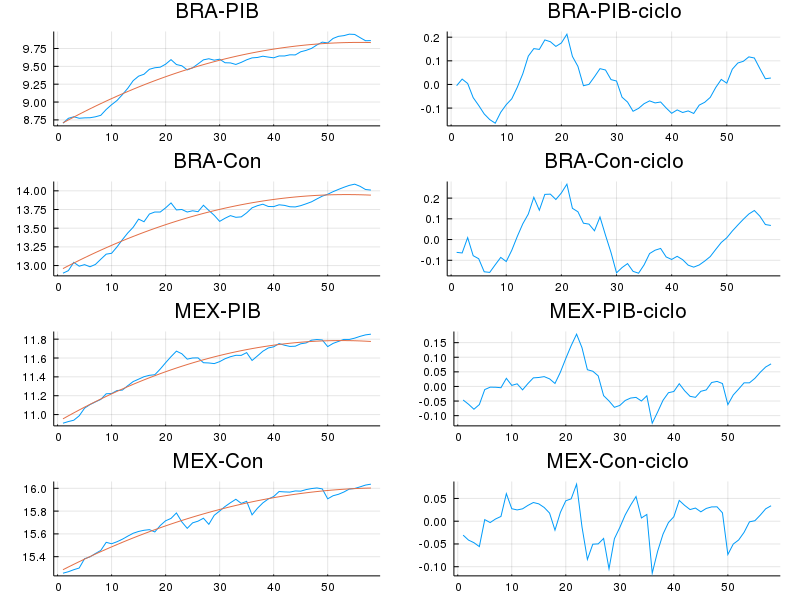

### Tendência e ciclo

Os gráficos indicam a perda de dinamismo da economia brasileira nas últimas décadas, com a tendência das séries indicando menores taxas de crescimento. Neste curso, não estudaremos os determinantes do crescimento econômico. Portanto, a tendência de longo-prazo será construída apenas por critérios estatísticos de ajuste aos dados. Mais adiante neste capítulo, voltaremos a essa discussão.

### Volatilidade

Os gráficos mostram, também, que as flutuações da economia brasileira em torno da tendência são maiores que as da economia mexicana. O desvio padrão do componente cíclico do *PIB* é de 10% para o Brasil e 5,6% para o México. No México, o consumo é menos volátil que o *PIB*; a razão dos desvios-padrão é 0,75. No Brasil, o consumo é mais volátil que a produção e a razão é 1,2.

Essas são características que nossos modelos tentarão explicar. Utilizaremos um mesmo modelo básico para analisar as economias de diversos países, as diferenças entre eles sendo capturadas por diferenças nos valores dos parâmetros do modelo. Como veremos, uma pegunta importante será: os valores dos parâmetros necessários para explicar o comportamento das séries empíricas são plausíveis?

### Correlação contemporânea

Em quase todos os países analisados por Uribe & Schmitt-Grohé, o consumo é pró-cíclico, ou seja, apresenta uma correlação positiva com a produção corrente: $cor(y_t,c_t)>0$. Nos nossos dados, a correlação entre os componentes cíclicos do *PIB* e do consumo é de 0,51 para o México e de 0,93 para o Brasil.

### Persistência

Informalmente, a persistência de uma série indica o quanto seu valor presente tende a ser parecido com os vizinhos. Uma medida de persistência é a correlação de primeira ordem: $cor(y_t,y_{t-1})$. Em séries macroeconômicas, esses valores tendem a ser elevados, , próximos de um, fazendo com que choques exógenos tenham efeitos duradouros. A correlação de primeira ordem para o componente cíclico do *PIB* é de 0,94 para o Brasil e de 0,85 para o México. A persistência do consumo é quase igual à da renda no Brasil (0,93) enquanto que no México é bem mais baixa (0,63).

## Extensões

Neste capítulo utilizamos, sem maior discussão, conceitos como nível de atividade, consumo, tendência e ciclo. Em um modelo teórico, é fácil definir uma variável, $C$, e chamá-la de *consumo*. Da mesma forma, é fácil estimar uma tendência quadrática e usá-la para calcular o *componente cíclico*. Mas qual a contrapartida desses conceitos teóricos nos dados empíricos? Quais séries devemos utilizar? Quais transformações fazer?

Nesta seção vamos abordar brevemente dois problemas associados aos dados que utilizamos acima.

### Tendência

Definimos o componente cíclico das séries como a diferença entre o valor observado e a estimativa de uma tendência quadrática. A primeira coisa a notar é que o componente cíclico foi construído, ele nunca é observado. Por exemplo, se tivéssemos utilizado uma tendência linear, teríamos outro componente cíclico.

Note que esse não é um problema de falta de dados. Algumas atividades econômicas podem ser difíceis de medir. Por exemplo, o nível de atividade da economia informal. Mas mesmo que observássemos todas as transações econômicas, tudo o que teríamos seria uma medida do nível de atividade. Jamais poderíamos medir a *tendência* da série. Ela precisa ser construída. E há várias maneiras de fazê-lo.

Discutir as alternativas para estimação da tendência de uma série envolveria conceitos de análise de séries temporais e nos forçaria a um longo desvio na discussão. Por isso, vamos apenas ilustrar que a definição da tendência pode ter um grande impacto na definição do componente cíclico.

Vimos acima como estimar uma tendência quadrática. Para estimar uma tendência linear, procedemos da mesma forma, obviamente, eliminando o termo quadrático da regressão. A figura abaixo, compara os componentes cíclicos do PIB brasileiro construídos com a tendência quadrática vista acima e com uma tendência linear.

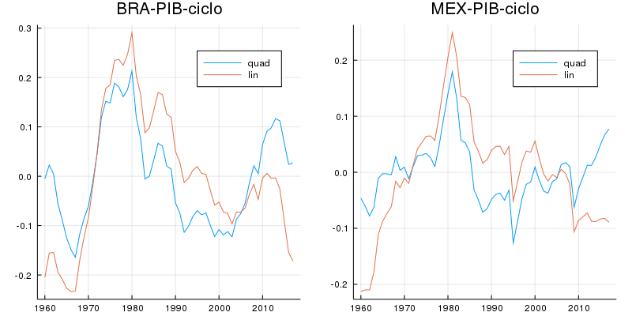

### Duráveis e não-duráveis

Quando um modelo macroeconômico fala de *consumo* quase sempre está se referindo ao consumo de não-duráveis. Do ponto de vista econômico, os gastos com o consumo de duráveis representam a aquisição de um estoque que gera serviços ao longo do tempo. Portanto, trata-se de uma atividade de investimento.

Infelizmente, em muitos casos, as séries econômicas disponíveis não desagregam o consumo entre duráveis e não-duráveis. E isso dificulta o confronto dos resultados do modelo com os dados empíricos. Para termos uma idéia da magnitude do problema, vejamos algumas séries de consumo disponíveis no *site* do *IPEA*.

Acesse o [Ipeadata](http://www.ipeadata.gov.br/Default.aspx). Em seguida: `macroeconômico-temas-produção`. Selecione as séries: (i) *Consumo aparente - bens de consumo duráveis - índice encadeado - dessaz(média 2012 = 100)* e *Consumo aparente - bens de consumo semi e não duráveis - índice encadeado - dessaz (média 2002= 100)* (2002 parece ser um erro de digitação). Clique no símbolo da lente de aumento (à direita, no alto) para exibir as séries.

[figure not shown]

A diferença na volatidade das duas séries é evidente. Se os dados desagregados não estivessem disponíveis, observaríamos apenas a soma das séries, o que dificultaria avaliar os modelos teóricos.

### Frequência

Definimos o componente cíclico como a diferença em relação a uma tendência quadrática em uma frequência anual.

A frequência anual torna as séries mais suaves, mas tende a ocultar eventos de curto prazo. Em análises do ciclo de negócios, é comum a utilização da frequência trimestral. No caso do Brasil, a frequência mensal é muito utilizada. Sucessivos "pacotes econômicos" e mudanças na metodologia de cálculo das séries, tornam difícil obter séries longas utilizáveis. Para não reduzir excessivamente o número de observações, séries mensais são utilizadas.

Além disso, como já mencionadao, podemos definir o componente cíclico de várias formas. Uma alternativa, quando as séries apresentam muita persistência, é utilizar as taxas de variação das séries. (Séries com raíz unitária, para quem já fez um curso de séries temporais.)

A figura abaixo mostra os mesmos dados de consumo acima,agora em uma frequência trimestral

[figure not shown]

## Tratamento dos dados

Esta seção mostra como obter e tratar os dados de forma a colocá-los no formato apropriado para a análise do ciclo de negócios.

### Download das séries

No site do [World Bank](http://www.worldbank.org/) acesse a página dos [World Development Indicators](https://databank.worldbank.org/data/reports.aspx?source=2&series=NY.GNP.PCAP.PP.CD&country=WLD#). Você deverá ver a seguinte tela:

[figure not shown]

Agora, vamos selecionar os países, as séries e os períodos de interesse. Siga aos seguintes passos no menu de navegação.

`Add Country`: `Brazil` `México`.

`Add Time`: `Select all`.

`Add Series`, `Economic Policy & Debt`:

(i) *National accounts-Local currency at constant prices*: `Aggregate indicators` , `GDP per capita (constant LCU)`;

(ii) *National accounts*: `Shares of GDP & other`, `Households and NPISHs final consumption expenditure (% of GDP)`;

Baixe os dados no formato que preferir; por exemplo, *Excel*. Vou nomear ese arquivo WDI.xlsx.

A planilha contém os dados em linha e com títulos. Transponha a planilha e elimine os títulos para ficar compatível com o código abaixo; ou adapte o código.

### Importação das séries

Na página principal do *Julia* faça o *upload* do arquivo *WDI.xlsx*, clicando no botão apropriado (à direita, em cima). Após o *upload*, o arquivo deverá aparecer na lista.

Há várias alternativas para manipular os dados. Vou utillizar o pacote [ExcelReaders](https://github.com/queryverse/ExcelReaders.jl).

Normalmente, para utilizar um pacote são necessários dois passos preliminares.

(i) Adicionar o pacote: `Pkg.add("ExcelReaders")`. Alguns pacotes fazem parte da biblioteca padrão e esse passo é desnecessário.

(ii) Inicializar o pacote, utilizando, no caso, o comando `using ExcelReaders`. Este comando carrega todo o pacote *ExcelReaders*. Isso é prático, mas consome espaço de memória. Uma alternativa é carregar apenas aquilo que vamos utilizar. Nesse caso, precisaremos do `readxlsheet`. O comando é: `import ExcelReaders: readxlsheet`.

Em seguida, precisamos ler os dados. (*Data* é o nome da planilha no arquivo WDI.xlsx) E vamos eliminar a primeira linha da matriz, que contém os nomes das variáveis, para termos uma matriz apenas com valores numéricos. Lembre, para executar uma célula: `Shift+Enter`.

```
Pkg.add("ExcelReaders");
import ExcelReaders: readxlsheet
dados = readxlsheet("WDI01.xlsx", "Data");
```

O *Anexo computacional* no final do capítulo contém todos os comandos apresentados a seguir em formato executável (células *Code*). Você pode reproduzir cada passo do texto executando as células apropriadas.

### Transformação das séries

Vamos trabalhar com várias matrizes. Consulte a documentação sobre [Arrays](https://docs.julialang.org/en/v0.6.2/stdlib/arrays/).

#### Criar as variáveis de *PIB per capita*

```
gbr=dados[:,1];
gmx=dados[:,2];
```

A primeira linha cria a variável *gbr* lendo todas as linhas da primeira coluna da matriz *dados*. Exclua o *ponto e vírgula* se quiser que os resultados sejam escritos na tela.

#### Criar as variáveis de consumo

Como os dados de consumo são percentuais do *PIB* é necessário transformá-los, multiplicando pelo *PIB per capita*.

```
cbr=gbr.*dados[:,3];
cmx=gmx.*dados[:,4];
```

A primeira linha cria a variável *cbr* multiplicando *gbr* pela terceira coluna de *dados*. Note o *ponto* ante do sinal de multiplicação. Ele indica que cada célula de *gbr* é multiplicada pela posição correspondente em *dados[:,3]*. Essa não é uma operação matricial, mas uma operação ponto a ponto.

#### Logaritmos das séries

Vamos trabalhar com os logarítmos do PIB e do consumo *per capita*.

```
gbr=log.(gbr);
gmx=log.(gmx);
cbr=log.(cbr);
cmx=log.(cmx);
```

A primeira linha substitui *gbr* por seu logarítmo. Poderíamos ter utilizado outro nome para a nova série.

Note o *ponto* após o *log*. Como visto acima, ele é necessário porque, por exemplo, *gbr* é um vetor. O *ponto* diz para o programa calcular o logarítmo de cada valor do vetor individualmente. Se *gbr* fosse um escalar, o ponto seria desnecessário.

Para obter ajuda sobre uma função, por exemplo, *log*: digite `? log` e `Shift-Enter` em uma célula de código.

### O componente cíclico das séries

Há várias alternativas para extrair o componente cíclico das séries. Vamos seguir o exemplo principal de [Uribe & Schmitt-Grohé](https://press.princeton.edu/titles/11032.html) e utilizar uma tendência quadrática.

#### A decomposição ciclo-tendência

Decompomos a série observada $(y_t)$ em dois componentes não-observados: a tendência ou componente secular $(y_t^S)$ e o ciclo $(y_t^C)$:

$ y_t = y_t^S + y_t^C $

O procedimento para estimar os dois componentes é bem simples. Basta estimar uma regressão tendo como variável dependente cada uma das séries de dados - portanto, quatro regressões. As variáveis independentes serão a constante, uma tendência linear $(t)$ e uma tendência quadrática $(t^2)$. O erro da regressão correponde ao componente da série $(y_t)$ não explicado pela tendência $(y_t^S)$ e, portanto, é o componente cíclico $(y_t^C)$. Ou seja:

$ y_t = \alpha_0 + \alpha_1.t + \alpha_2.t^2 + \epsilon_t $

$ y_t^S = \hat{\alpha}_0 + \hat{\alpha}_1.t + \hat{\alpha}_1.t^2 $

$ y_t^C = y_t - y_t^S = y_t - (\hat{\alpha}_0 + \hat{\alpha}_1.t + \hat{\alpha}_1.t^2) $

#### O pacote para a estimação

Para estimarmos as quatro regressões, usaremos o pacote [MultivariateStats](https://multivariatestatsjl.readthedocs.io/en/stable/index.html) com o procedimento [llsq](https://multivariatestatsjl.readthedocs.io/en/stable/lreg.html) (linear least squares).

```
Pkg.add("MultivariateStats")
import MultivariateStats: llsq
```

A sintaxe para o comando de regressão é:

```
a = llsq(X, y; bias=false)
```

a: vetor com os parâmetros estimados. X: matriz com os regressores. y: vetor com a variável dependente. O comando *bias=false* está explicado na documentação.

#### As variáveis para a estimação

Precisamos de um vetor constante e das tendência linear e quadrática.

(i) Medir o tamanho das séries e armazernar o valor na variável *T*. Para isso, utilizamos o comando *length*. Consulte a documentação sobre [Arrays](https://docs.julialang.org/en/v0.6.2/stdlib/arrays/). (Se as séries tivessem tamanhos diferentes seria necessário fazer isso para cada uma delas.)

```
T=length(gbr);
```

(ii) Construir a série de anos para os eixos horizontais. O comando [LinRange](https://docs.julialang.org/en/v1/base/collections/index.html) constrói a série.

```
ano = LinRange(1960,2017,T);
```

Terceiro, as tendências linear e quadrática para os regressores.

```
time = LinRange(1,T,T);
time2 = time.^2;
X = [ones(T) time time2];
```

Para extrair apenas uma tendência linear, basta subtituir a matriz de regressores por:

```
X = [ones(T) time];
```

```
y = cbr;
a = llsq(X, y; bias=false);
gdpargs = X * a;
gdpargc = gdparg - gdpargs;
```

### Gráficos

Para fazer os gráficos, usaremos o pacote [Plots](http://docs.juliaplots.org/latest/tutorial/#tutorial-1).

```
Pkg.add("Plots")
import Plots: plot
```

Vamos criar quatro gráficos para as séries brasileiras e os mesmos quatro para as mexicanas.

Primeiro, um gráfico com os valores observados para o *PIB* e os valores estimados para a tendência.

```
p1 = plot(time, [gdparg gdpargs])
```

Segundo, um gráfico com o componente cíclico estimado para o *PIB*.

```
p2 = plot(time, gdpargc)
```

Terceiro e quarto, de forma equivalente para o consumo.

```
p3 = plot(time, [conarg conargs])
p4 = plot(time, conargc)
```

Quinto a oitavo, idem para as séries mexicanas.

```
p5 = plot(time, [gmx gmxs], title="MEX-PIB")
p6 = plot(time, gmxc,  title="MEX-PIB-ciclo")
p7 = plot(time, [cmx cmxs], title="MEX-Con")
p8 = plot(time, cmxc, title="MEX-Con-ciclo")
```

Finalmente, empacotamos tudo em um único gráfico.

```
plot(p1,p2,p3,p4,p5,p6,p7,p8, layout=(4,2), legend=false)
```

Se você quiser fazer o gráfico no formato de figura exportável, substitua a última linha por:

```
plot(p1,p2,p3,p4,p5,p6,p7,p8, layout=(4,2), legend=false, fmt = :png, size = (800, 600))
```

### Estatísticas descritivas

Vejamos algumas estatísticas descritivas para os componentes cíclicos das séries. Calcularemos desvios padrão (*std*) e correlações (*cor*). Para isso, utilizaremos o pacote [StatsBase](http://juliastats.github.io/StatsBase.jl/latest/index.html).

```
Pkg.add("StatsBase")
import StatsBase: std, cor
```

#### Desvios padrão

Desvios padrão dos componentes cíclicos das séries. O desvio padrão do *PIB* e a razão entre os desvios padrão do *PIB* e do consumo.

```
[std(gbrc) std(cbrc)/std(gbrc);
 std(gmxc) std(cmxc)/std(gmxc)]
```

#### Correlações contemporâneas

Correlação contemporânea entre a produção e o consumo correntes: $cor(y_t,c_t)>0$

```
cor([gbrc cbrc])
cor([gmxc cmxc])
```

#### Persistência

Autocorrelações de primeira ordem das séries: $cor(y_t,y_{t-1})$.

```
cor([gbrc[2:58] gbrc[1:57]])
cor([gmxc[2:58] gmxc[1:57]])
cor([cbrc[2:58] cbrc[1:57]])
cor([cmxc[2:58] cmxc[1:57]])
```

### Imagens

Os *notebooks* do curso apresentam várias capturas de tela (*screeshots*). Há mais de uma maneira de inserir imagens em um *notebook*.

A mais simples é via *Alt+PrtScn* seguida de *Ctrl+v*. Isso funciona sem problemas desde que você queira utilizar seu *notebook* apenas no formato .ipynb *e não queira exportá-lo para outro formato, por exemplo* HTML*. Nesse caso, se você tiver inserido mais de uma imagem, a versão* HTML* apresentará várias cópias de uma mesma imagem e não as diferentes imagens. A maneira mais simples que eu encontrei para eliminar esse problema é a seguinte.

(i) Faça a captura da tela usando a *Ferramenta de Captura* do *Windows* (`Iniciar-Acessórios`). (ii) Faça a captura e grave o arquivo. (iii) Insira a imagem no *notebook* usando o menu `Edit-Insert Image` ou arraste a imagem para o *notebook*. (iv) Repita para novas imagens, gravando cada arquivo com um nome diferente. Em seguida, pode deletar os arquivos, caso queira. (v) Crie a versão *HTML* usando `File-Download as-HTML`.

## Conclusão

Neste capítulo, definimos algumas das características do problema que iremos analisar: o comportamento cíclico das variáveis macroeconômicas. Vimos que a discussão do ciclo econômico envolve explicar características como volatidade, persistência *etc*... Isso sugere que um macroeconomista precisa estar familiarizado com a análise de séries temporais.

Um ponto importante ilustrado neste capítulo é que é necessário prestar muita atenção aos dados que serão utilizados na análise. Definições diferentes (duráveis X não-duráveis), frequências diferentes (anual X trimestral X mensal), transformações diferentes (tendência linear X tendência quadrática X taxas de variação X ...) produzem imagens diferentes dos problemas que vamos estudar.

Se você está começando a utilizar o *Jupyter-Julia* é normal ficar um pouco perdido com tantos comandos, pacotes *etc*... Consulte regularmente o *Help* e os tutoriais e use estes exemplos como ponto de partida. No mais, o jeito é treinar.

Se você não fez um curso de séries temporais, não se preocupe com os detalhes de como as tendências das séries são estimadas. Por outro lado, se você quer ser um macroeconomista profissional e não fez um curso de séries temporais ... FAÇA!

## Exercícios

**Exercício 1**

Escolha dois países, refaça os exemplos acima e compare os resultados.

♥

## Referências e leitura adicional

O capítulo 2 de [Uribe & Schmitt-Grohé](https://press.princeton.edu/titles/11032.html) apresenta as principais características das flutuações cíclicas de diversas economias. O livro contém material avançado, mas o capítulo 2, descritivo, é fácil de ler. Esses [slides](http://www.columbia.edu/~mu2166/book/empirics/slides_empirics.pdf) fazem um resumo do capítulo.

O [Federal Reserve Bank of Dallas](https://www.dallasfed.org/research/basics) apresenta um manual básico sobre tratamento de dados econômicos.

## Anexo computacional

Este anexo reúne o código completo apresentado no texto.

(i) A importação de todos os pacotes foi concentrada no início do programa, mas isso não é necessário.

(ii) Os pacotes são: ExcelReaders, [MultivariateStats](https://github.com/JuliaStats/MultivariateStats.jl), [StatsBase](https://github.com/JuliaStats/StatsBase.jl) e [Plots](http://docs.juliaplots.org/latest/). Veja, também, [QuantEcon](https://lectures.quantecon.org/jl/).

(iii) A planilha *Excel* com os dados deve estar no mesmo *folder* que este *notebook*, dentro do *JuliaBox*. A minha planilha é: *WDI01.xlsx*.

(iv) A maioria dos comandos é auto-explicativa e está descrita no texto. Por via das dúvidas:

*llsq*: linear least squares, para as regressões. *std*: desvio padrão. *cor*: correlação. *plot*: gráficos.

(v) O código para as variáveis é o seguinte. No início do nome, $g$ indica *PIB* e $c$ indica consumo. Em seguida, $br$ e $mx$ indicam *Brasil* e *México*, respectivamente. $c$ no final do nome da variável indica o componente cíclico. Assim: $gbr$ é o *PIB* brasileiro e $cmxc$ é o componente cíclico do consumo mexicano.

(vi) Este *notebook* utiliza vários pacotes. Para poupar espaço na memória, antes de salvar o *notebook*: `Kernel` e `Restart & Clear Ouptut`.

```julia
# Importação dos pacotes

Pkg.add("ExcelReaders")
import ExcelReaders: readxlsheet

Pkg.add("MultivariateStats")
import MultivariateStats: llsq

Pkg.add("StatsBase")
import StatsBase: std, cor

Pkg.add("Plots")
import Plots: plot
```

```julia
# Leitura e transformação dos dados

#Leitura dos dados
dados = readxlsheet("WDI01.xlsx","Data") ;

# Criação das variáveis
gbr = dados[:,1];
gmx = dados[:,2];
cbr = gbr.*dados[:,3];
cmx = gmx.*dados[:,4];

# Transformação logarítmica
gbr = log.(gbr);
gmx = log.(gmx);
cbr = log.(cbr);
cmx = log.(cmx);
```

```julia
# Séries para estimação

T=length(gbr);
ano = LinRange(1960,2017,T);
time = LinRange(1,58,58);
time2 = time.^2;
X = [ones(58) time time2];   # tendência quadrática
# X = [ones(58) time];       # tendência linear
```

```julia
# Regressões

y = gbr;
a = llsq(X, y; bias=false);
gbrs = X * a;
gbrc = gbr - gbrs;

y = gmx;
a = llsq(X, y; bias=false);
gmxs = X * a;
gmxc = gmx - gmxs;

y = cbr;
a = llsq(X, y; bias=false);
cbrs = X * a;
cbrc = cbr - cbrs;

y = cmx;
a = llsq(X, y; bias=false);
cmxs = X * a;
cmxc = cmx - cmxs;
```

```julia
# Gráficos

p1 = plot(ano, [gbr gbrs], title="BRA-PIB")

p2 = plot(ano, gbrc, title="BRA-PIB-ciclo")

p3 = plot(ano, [cbr cbrs], title="BRA-Con")

p4 = plot(ano, cbrc, title="BRA-Con-ciclo")

p5 = plot(ano, [gmx gmxs], title="MEX-PIB")

p6 = plot(ano, gmxc,  title="MEX-PIB-ciclo")

p7 = plot(ano, [cmx cmxs], title="MEX-Con")

p8 = plot(ano, cmxc, title="MEX-Con-ciclo")

plot(p1,p2,p3,p4,p5,p6,p7,p8, layout=(4,2), legend=false)
#plot(p1,p2,p3,p4,p5,p6,p7,p8, layout=(4,2), legend=false, fmt = :png, size = (800, 600))
```

```julia
# Regressões - tendência linear

X1 = [ones(58) time];   # tendência quadrática

y = gbr;
a = llsq(X1, y; bias=false);
gbrs1 = X1 * a;
gbrc1 = gbr - gbrs1;

y = gmx;
a = llsq(X1, y; bias=false);
gmxs1 = X1 * a;
gmxc1 = gmx - gmxs1;

p9 = plot(ano, [gbrc gbrc1], title="BRA-PIB-ciclo")
p10 = plot(ano, [gmxc gmxc1], title="MEX-PIB-ciclo")
plot(p9,p10, layout=(1,2), label=["quad", "lin"], fmt = :png, size = (800, 400))
```

```julia
# Estatísticas

# Desvios padrão

[std(gbrc) std(cbrc)/std(gbrc);
 std(gmxc) std(cmxc)/std(gmxc)]
```

```julia
# Correlações contemporâneas

x = cor([gbrc cbrc])     # Matriz (2x2)
y = cor([gmxc cmxc])     # Matriz (2x2)

[x[1,2] y[1,2]]          # As corrrelações em cada matriz
```

Persistência

Para calcular a autocorrelação de primeira ordem de uma série, precisamos dos seus valores contemporâneos $(y_t)$ e dos seus valores defasados $(y_{t_1})$. Por exemplo, para o *PIB* brasileiro, teremos: $y_t=gbrc[2:58]$ e $y_{t-1}=gbrc[1:57]$.

```julia
w = cor([gbrc[2:58] gbrc[1:57]])     # Matriz (2x2)
x = cor([gmxc[2:58] gmxc[1:57]])     # Matriz (2x2)
y = cor([cbrc[2:58] cbrc[1:57]])     # Matriz (2x2)
z = cor([cmxc[2:58] cmxc[1:57]])     # Matriz (2x2)

[w[1,2] x[1,2] y[1,2] z[1,2]]        # As corrrelações em cada matriz
```